# Forest Cover Classification

# Dataset from Kaggle for predicting and classifying tree types from geospatial data

## Dataset Description

### The study area includes four wilderness areas located in the Roosevelt National Forest of northern Colorado. Each observation is a 30m x 30m patch. You are asked to predict an integer classification for the forest cover type. The seven types are:

- 1 - Spruce/Fir
- 2 - Lodgepole Pine
- 3 - Ponderosa Pine
- 4 - Cottonwood/Willow
- 5 - Aspen
- 6 - Douglas-fir
- 7 - Krummholz

### The training set (15120 observations) contains both features and the Cover_Type.

### Data Fields

- Elevation - Elevation in meters
- Aspect - Aspect in degrees azimuth
- Slope - Slope in degrees
- Horizontal_Distance_To_Hydrology - Horz Dist to nearest surface water features
- Vertical_Distance_To_Hydrology - Vert Dist to nearest surface water features
- Horizontal_Distance_To_Roadways - Horz Dist to nearest roadway
- Hillshade_9am (0 to 255 index) - Hillshade index at 9am, summer solstice
- Hillshade_Noon (0 to 255 index) - Hillshade index at noon, summer solstice
- Hillshade_3pm (0 to 255 index) - Hillshade index at 3pm, summer solstice
- Horizontal_Distance_To_Fire_Points - Horz Dist to nearest wildfire ignition points
- Wilderness_Area (4 binary columns, 0 = absence or 1 = presence) - Wilderness area designation
- Soil_Type (40 binary columns, 0 = absence or 1 = presence) - Soil Type designation
- Cover_Type (7 types, integers 1 to 7) - Forest Cover Type designation

## The goal is to classify the rows into which tree type (cover type) they belong.

```r
library(tidyverse)
library(reshape2)
# read in the raw data
f1 <- read.csv("c:/Users/tscott/OneDrive - Eastside Preparatory School/Courses/DataScience_2/data/forest-cover-type-prediction/train.csv")

# check it out
summary(f1)
```

```
       Id          Elevation        Aspect          Slope      Horizontal_Distance_To_Hydrology Vertical_Distance_To_Hydrology
 Min.   :    1   Min.   :1863   Min.   :  0.0   Min.   : 0.0   Min.   :   0.0                   Min.   :-146.00
 1st Qu.: 3781   1st Qu.:2376   1st Qu.: 65.0   1st Qu.:10.0   1st Qu.:  67.0                   1st Qu.:   5.00
 Median : 7560   Median :2752   Median :126.0   Median :15.0   Median : 180.0                   Median :  32.00
 Mean   : 7560   Mean   :2749   Mean   :156.7   Mean   :16.5   Mean   : 227.2                   Mean   :  51.08
 3rd Qu.:11340   3rd Qu.:3104   3rd Qu.:261.0   3rd Qu.:22.0   3rd Qu.: 330.0                   3rd Qu.:  79.00
 Max.   :15120   Max.   :3849   Max.   :360.0   Max.   :52.0   Max.   :1343.0                   Max.   : 554.00
 Horizontal_Distance_To_Roadways Hillshade_9am   Hillshade_Noon Hillshade_3pm   Horizontal_Distance_To_Fire_Points
 Min.   :   0                    Min.   :  0.0   Min.   : 99    Min.   :  0.0   Min.   :   0
 1st Qu.: 764                    1st Qu.:196.0   1st Qu.:207    1st Qu.:106.0   1st Qu.: 730
 Median :1316                    Median :220.0   Median :223    Median :138.0   Median :1256
 Mean   :1714                    Mean   :212.7   Mean   :219    Mean   :135.1   Mean   :1511
 3rd Qu.:2270                    3rd Qu.:235.0   3rd Qu.:235    3rd Qu.:167.0   3rd Qu.:1988
 Max.   :6890                    Max.   :254.0   Max.   :254    Max.   :248.0   Max.   :6993
 Wilderness_Area1 Wilderness_Area2 Wilderness_Area3 Wilderness_Area4   Soil_Type1        Soil_Type2       Soil_Type3
 Min.   :0.0000   Min.   :0.000    Min.   :0.0000   Min.   :0.0000   Min.   :0.00000   Min.   :0.0000   Min.   :0.00000
 1st Qu.:0.0000   1st Qu.:0.000    1st Qu.:0.0000   1st Qu.:0.0000   1st Qu.:0.00000   1st Qu.:0.0000   1st Qu.:0.00000
 Median :0.0000   Median :0.000    Median :0.0000   Median :0.0000   Median :0.00000   Median :0.0000   Median :0.00000
 Mean   :0.2379   Mean   :0.033    Mean   :0.4199   Mean   :0.3092   Mean   :0.02348   Mean   :0.0412   Mean   :0.06362
 3rd Qu.:0.0000   3rd Qu.:0.000    3rd Qu.:1.0000   3rd Qu.:1.0000   3rd Qu.:0.00000   3rd Qu.:0.0000   3rd Qu.:0.00000
 Max.   :1.0000   Max.   :1.000    Max.   :1.0000   Max.   :1.0000   Max.   :1.00000   Max.   :1.0000   Max.   :1.00000
   Soil_Type4        Soil_Type5        Soil_Type6        Soil_Type7   Soil_Type8         Soil_Type9         Soil_Type10
 Min.   :0.00000   Min.   :0.00000   Min.   :0.00000   Min.   :0    Min.   :0.00e+00   Min.   :0.0000000   Min.   :0.0000
 1st Qu.:0.00000   1st Qu.:0.00000   1st Qu.:0.00000   1st Qu.:0    1st Qu.:0.00e+00   1st Qu.:0.0000000   1st Qu.:0.0000
 Median :0.00000   Median :0.00000   Median :0.00000   Median :0    Median :0.00e+00   Median :0.0000000   Median :0.0000
 Mean   :0.05575   Mean   :0.01091   Mean   :0.04299   Mean   :0    Mean   :6.61e-05   Mean   :0.0006614   Mean   :0.1417
 3rd Qu.:0.00000   3rd Qu.:0.00000   3rd Qu.:0.00000   3rd Qu.:0    3rd Qu.:0.00e+00   3rd Qu.:0.0000000   3rd Qu.:0.0000
 Max.   :1.00000   Max.   :1.00000   Max.   :1.00000   Max.   :0    Max.   :1.00e+00   Max.   :1.0000000   Max.   :1.0000
  Soil_Type11       Soil_Type12       Soil_Type13       Soil_Type14       Soil_Type15  Soil_Type16       Soil_Type17
 Min.   :0.00000   Min.   :0.00000   Min.   :0.00000   Min.   :0.00000   Min.   :0    Min.   :0.00000   Min.   :0.00000
 1st Qu.:0.00000   1st Qu.:0.00000   1st Qu.:0.00000   1st Qu.:0.00000   1st Qu.:0    1st Qu.:0.00000   1st Qu.:0.00000
 Median :0.00000   Median :0.00000   Median :0.00000   Median :0.00000   Median :0    Median :0.00000   Median :0.00000
 Mean   :0.02685   Mean   :0.01501   Mean   :0.03148   Mean   :0.01118   Mean   :0    Mean   :0.00754   Mean   :0.04048
 3rd Qu.:0.00000   3rd Qu.:0.00000   3rd Qu.:0.00000   3rd Qu.:0.00000   3rd Qu.:0    3rd Qu.:0.00000   3rd Qu.:0.00000
 Max.   :1.00000   Max.   :1.00000   Max.   :1.00000   Max.   :1.00000   Max.   :0    Max.   :1.00000   Max.   :1.00000
  Soil_Type18        Soil_Type19        Soil_Type20        Soil_Type21        Soil_Type22       Soil_Type23
 Min.   :0.000000   Min.   :0.000000   Min.   :0.000000   Min.   :0.000000   Min.   :0.00000   Min.   :0.00000
 1st Qu.:0.000000   1st Qu.:0.000000   1st Qu.:0.000000   1st Qu.:0.000000   1st Qu.:0.00000   1st Qu.:0.00000
 Median :0.000000   Median :0.000000   Median :0.000000   Median :0.000000   Median :0.00000   Median :0.00000
 Mean   :0.003968   Mean   :0.003042   Mean   :0.009193   Mean   :0.001058   Mean   :0.02282   Mean   :0.05007
```

[output cut: 8 more lines]

```
 Max.   :1.000   Max.   :1.00e+00   Max.   :1.000000   Max.   :1.0000000   Max.   :1.0000000   Max.   :1.00000
  Soil_Type30       Soil_Type31       Soil_Type32       Soil_Type33       Soil_Type34        Soil_Type35
 Min.   :0.00000   Min.   :0.00000   Min.   :0.00000   Min.   :0.00000   Min.   :0.000000   Min.   :0.000000
 1st Qu.:0.00000   1st Qu.:0.00000   1st Qu.:0.00000   1st Qu.:0.00000   1st Qu.:0.000000   1st Qu.:0.000000
 Median :0.00000   Median :0.00000   Median :0.00000   Median :0.00000   Median :0.000000   Median :0.000000
 Mean   :0.04795   Mean   :0.02196   Mean   :0.04563   Mean   :0.04074   Mean   :0.001455   Mean   :0.006746
 3rd Qu.:0.00000   3rd Qu.:0.00000   3rd Qu.:0.00000   3rd Qu.:0.00000   3rd Qu.:0.000000   3rd Qu.:0.000000
 Max.   :1.00000   Max.   :1.00000   Max.   :1.00000   Max.   :1.00000   Max.   :1.000000   Max.   :1.000000
  Soil_Type36         Soil_Type37        Soil_Type38       Soil_Type39       Soil_Type40        Cover_Type
 Min.   :0.0000000   Min.   :0.000000   Min.   :0.00000   Min.   :0.00000   Min.   :0.00000   Min.   :1
 1st Qu.:0.0000000   1st Qu.:0.000000   1st Qu.:0.00000   1st Qu.:0.00000   1st Qu.:0.00000   1st Qu.:2
 Median :0.0000000   Median :0.000000   Median :0.00000   Median :0.00000   Median :0.00000   Median :4
 Mean   :0.0006614   Mean   :0.002249   Mean   :0.04815   Mean   :0.04345   Mean   :0.03036   Mean   :4
 3rd Qu.:0.0000000   3rd Qu.:0.000000   3rd Qu.:0.00000   3rd Qu.:0.00000   3rd Qu.:0.00000   3rd Qu.:6
 Max.   :1.0000000   Max.   :1.000000   Max.   :1.00000   Max.   :1.00000   Max.   :1.00000   Max.   :7
```

```r
# remove Id column and set categorical variables to be factor variables
forestCover <- f1 %>% select(-Id)
forestCover[,11:ncol(forestCover)] <- lapply(forestCover[,11:ncol(forestCover)], as.factor)

# inspect
str(forestCover)
```

```
'data.frame':   15120 obs. of  55 variables:
 $ Elevation                         : int  2596 2590 2804 2785 2595 2579 2606 2605 2617 2612 ...
 $ Aspect                            : int  51 56 139 155 45 132 45 49 45 59 ...
 $ Slope                             : int  3 2 9 18 2 6 7 4 9 10 ...
 $ Horizontal_Distance_To_Hydrology  : int  258 212 268 242 153 300 270 234 240 247 ...
 $ Vertical_Distance_To_Hydrology    : int  0 -6 65 118 -1 -15 5 7 56 11 ...
 $ Horizontal_Distance_To_Roadways   : int  510 390 3180 3090 391 67 633 573 666 636 ...
 $ Hillshade_9am                     : int  221 220 234 238 220 230 222 222 223 228 ...
 $ Hillshade_Noon                    : int  232 235 238 238 234 237 225 230 221 219 ...
 $ Hillshade_3pm                     : int  148 151 135 122 150 140 138 144 133 124 ...
 $ Horizontal_Distance_To_Fire_Points: int  6279 6225 6121 6211 6172 6031 6256 6228 6244 6230 ...
 $ Wilderness_Area1                  : Factor w/ 2 levels "0","1": 2 2 2 2 2 2 2 2 2 2 ...
 $ Wilderness_Area2                  : Factor w/ 2 levels "0","1": 1 1 1 1 1 1 1 1 1 1 ...
 $ Wilderness_Area3                  : Factor w/ 2 levels "0","1": 1 1 1 1 1 1 1 1 1 1 ...
 $ Wilderness_Area4                  : Factor w/ 2 levels "0","1": 1 1 1 1 1 1 1 1 1 1 ...
```

[output cut: 41 more lines]

```r
# two of the columns have only 1 level, Soil_Type7 and 15, so those will not be useful for any model
forestCover <- forestCover %>% select(-Soil_Type7, -Soil_Type15)

# how many of each cover type? Very balanced.
table(forestCover$Cover_Type)
```

```
   1    2    3    4    5    6    7
2160 2160 2160 2160 2160 2160 2160
```

## Check out the frequency distribution of the numeric features

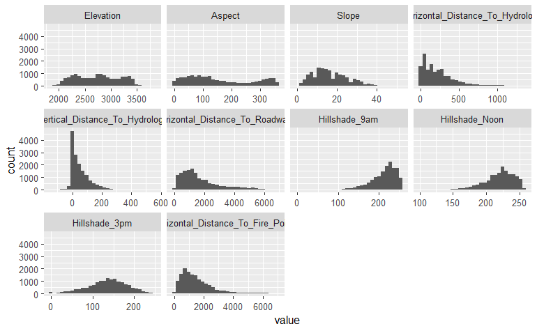

```r
# histograms of columns 1-10
# tips from https://stackoverflow.com/questions/13035834/plot-every-column-in-a-data-frame-as-a-histogram-on-one-page-using-ggplot

# need to melt into single DF
df <- melt(forestCover[,1:10])
#View(df)

# now can plot using facets, scales = free_x since each has its own range
ggplot(data=df, aes(x=value)) + facet_wrap(~variable, scales = "free_x") +
  geom_histogram()
```

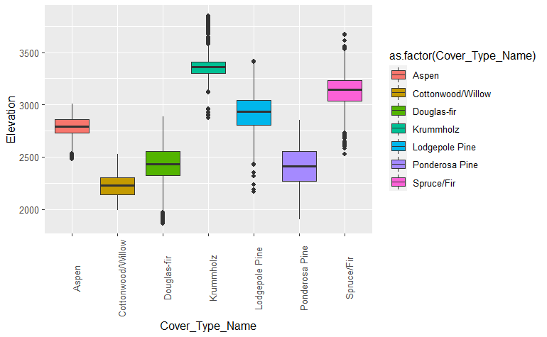

```r
# 1 - Spruce/Fir
# 2 - Lodgepole Pine
# 3 - Ponderosa Pine
# 4 - Cottonwood/Willow
# 5 - Aspen
# 6 - Douglas-fir
# 7 - Krummholz

# add in cover type names for better plots
forestCover <- forestCover %>% mutate(Cover_Type_Name = case_when(
  Cover_Type == "1" ~ "Spruce/Fir",
  Cover_Type == "2" ~ "Lodgepole Pine",
  Cover_Type == "3" ~ "Ponderosa Pine",
  Cover_Type == "4" ~ "Cottonwood/Willow",
  Cover_Type == "5" ~ "Aspen",
  Cover_Type == "6" ~ "Douglas-fir",
  TRUE ~ "Krummholz"
))

# some boxplots by cover type: Elevation, Hydrology, Aspect
ggplot(data=forestCover) +
  geom_boxplot(aes(x=Cover_Type_Name, y=Elevation, fill=as.factor(Cover_Type_Name))) +
  theme(axis.text.x=element_text(angle=90))
```

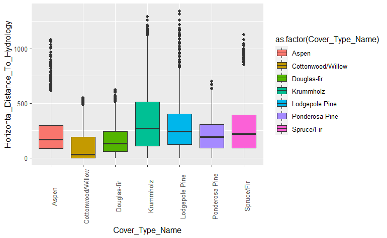

```r
ggplot(data=forestCover) +
  geom_boxplot(aes(x=Cover_Type_Name, y=Horizontal_Distance_To_Hydrology, fill=as.factor(Cover_Type_Name))) +
  theme(axis.text.x=element_text(angle=90))
```

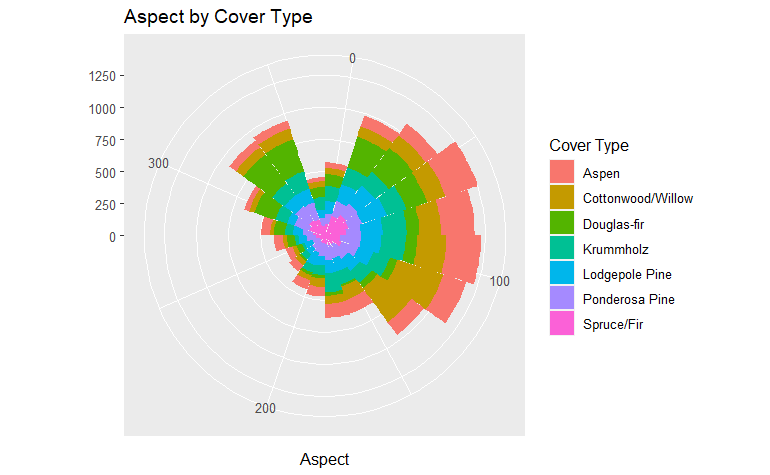

```r
ggplot(forestCover, aes(x=Aspect, fill=as.factor(Cover_Type_Name))) +
  geom_histogram(bins = 20) +
  coord_polar() +
  labs(title="Aspect by Cover Type", x="Aspect", y="") +
  scale_fill_discrete(name="Cover Type")
```

## There are certainly some differences between tree cover type, e.g. Aspen and Cottonwood/Willow prefer eastern aspects

### Let’s try k-means clustering by the numerics, knowing there are 7 clusters and see how separable these are

```r
#install.packages("useful")
library(useful) # for plotting k-means clusters
library(caTools) # for sample splitting

# get numeric columns only for k-means
forestClust <- forestCover %>% select(1:10)

# sample it since plotting clusters takes too long
set.seed(732)

# sample to 20% of the data
forestClustSample <- forestClust %>% sample_frac(0.20)


start1 <- Sys.time()
#build k-means clusters
forest7 <- kmeans(forestClustSample, centers = 7)
forest7
```

```
K-means clustering with 7 clusters of sizes 272, 982, 289, 653, 496, 165, 167

Cluster means:
  Elevation   Aspect    Slope Horizontal_Distance_To_Hydrology Vertical_Distance_To_Hydrology Horizontal_Distance_To_Roadways
1  3145.603 144.0772 13.64338                         323.7904                       52.68750                       3151.7684
2  2376.445 159.7770 19.87169                         171.6629                       52.47454                        850.3859
3  2969.412 140.0138 13.48789                         233.9170                       35.99308                       1730.1765
4  2726.315 143.6937 16.74579                         228.4181                       52.02757                        848.2649
5  2990.298 160.6190 15.83266                         251.1089                       53.82863                       2133.7218
6  3106.248 162.2424 11.87273                         255.1758                       43.38182                       4877.2909
7  3176.497 183.3772 13.20958                         345.8683                       65.44910                       4425.1377
  Hillshade_9am Hillshade_Noon Hillshade_3pm Horizontal_Distance_To_Fire_Points
1      216.2831       223.6728      138.7574                          2198.6213
2      207.5835       212.6894      131.5428                           652.4613
3      215.9896       223.4671      138.9481                          2817.1765
```

[output cut: 33 more lines]

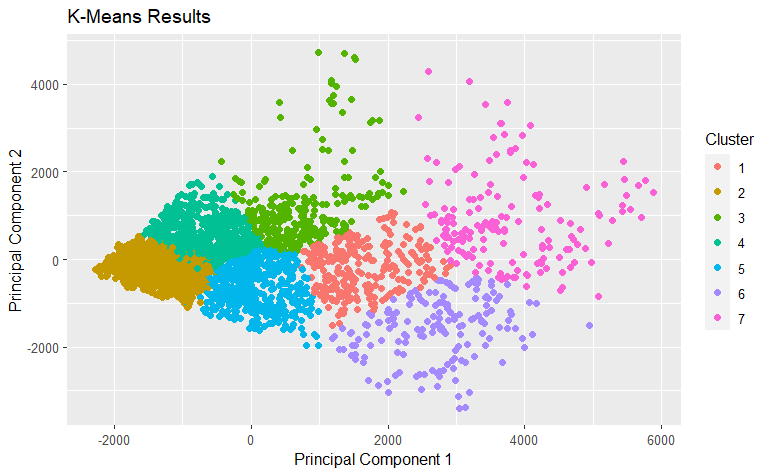

```r
# how do they look?
plot(forest7, data=forestClustSample)
```

```r
end1 <- Sys.time()          # Finishing time
(time1 <- end1 - start1) # total time
```

```
Time difference of 1.156678 mins
```

## They look pretty cleanly divided with only two principal components, so we ought to be able to classify them with decent accuracy

## Try a Decision Tree and maybe Random Forest. Evaluate using confusionMatrix from caret package for accuracy.

```r
library(rpart)
library(rpart.plot)
library(randomForest)
library(e1071)
library(caret)
library(RColorBrewer)
library(rattle)
# drop name column now
forestCover <- forestCover %>% select(-Cover_Type_Name)

# create train/test split
set.seed(732)
sample <- sample.split(forestCover$Elevation, SplitRatio = 0.7)
forestTrain <- subset(forestCover, sample == TRUE)
forestTest <- subset(forestCover, sample == FALSE)

str(forestTest)
```

```
'data.frame':   4512 obs. of  53 variables:
 $ Elevation                         : int  2590 2804 2606 2617 2742 2609 2517 2504 2489 2749 ...
 $ Aspect                            : int  56 139 45 45 134 214 72 0 163 98 ...
 $ Slope                             : int  2 9 7 9 22 7 7 4 10 30 ...
 $ Horizontal_Distance_To_Hydrology  : int  212 268 270 240 150 150 85 95 30 124 ...
 $ Vertical_Distance_To_Hydrology    : int  -6 65 5 56 69 46 6 5 -4 53 ...
 $ Horizontal_Distance_To_Roadways   : int  390 3180 633 666 3215 771 595 691 849 3316 ...
 $ Hillshade_9am                     : int  220 234 222 223 248 213 228 214 230 252 ...
 $ Hillshade_Noon                    : int  235 238 225 221 224 247 227 232 243 183 ...
 $ Hillshade_3pm                     : int  151 135 138 133 92 170 133 156 145 36 ...
 $ Horizontal_Distance_To_Fire_Points: int  6225 6121 6256 6244 6091 6211 5607 5572 5486 6005 ...
 $ Wilderness_Area1                  : Factor w/ 2 levels "0","1": 2 2 2 2 2 2 2 2 2 2 ...
 $ Wilderness_Area2                  : Factor w/ 2 levels "0","1": 1 1 1 1 1 1 1 1 1 1 ...
 $ Wilderness_Area3                  : Factor w/ 2 levels "0","1": 1 1 1 1 1 1 1 1 1 1 ...
 $ Wilderness_Area4                  : Factor w/ 2 levels "0","1": 1 1 1 1 1 1 1 1 1 1 ...
```

[output cut: 39 more lines]

```r
# build the tree
start1 <- Sys.time()
myTree <- rpart(data=forestTrain, Cover_Type ~ .)
end1 <- Sys.time()          # Finishing time
(time1 <- end1 - start1) # total time
```

```
Time difference of 1.27389 secs
```

```r
# check it out and plot the tree
printcp(myTree)
```

```
Classification tree:
rpart(formula = Cover_Type ~ ., data = forestTrain)

Variables actually used in tree construction:
[1] Elevation        Hillshade_9am    Soil_Type10      Soil_Type12      Wilderness_Area1

Root node error: 9082/10608 = 0.85615

n= 10608

        CP nsplit rel error  xerror      xstd
1 0.165712      0   1.00000 1.01431 0.0038337
2 0.137855      1   0.83429 0.83847 0.0051038
3 0.093041      2   0.69643 0.69621 0.0055647
4 0.085224      3   0.60339 0.64435 0.0056399
5 0.026316      4   0.51817 0.52566 0.0056419
6 0.021031      5   0.49185 0.50451 0.0056175
7 0.017287      6   0.47082 0.48844 0.0055938
8 0.011231      8   0.43625 0.44957 0.0055180
9 0.010000      9   0.42502 0.44340 0.0055035
```

[figure not shown]

```r
#summary(myTree)
fancyRpartPlot(myTree)
```

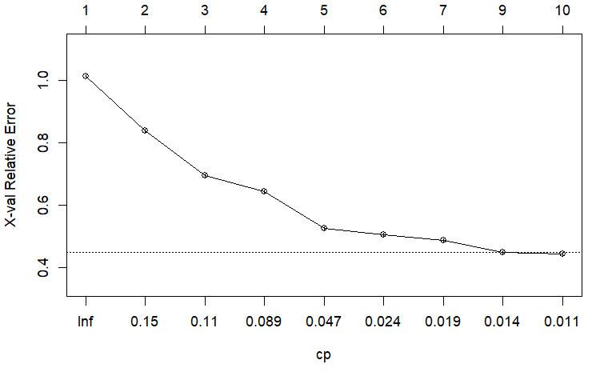

```r
plotcp(myTree)
```

```r
# try lowering cp
# prunedTreeLessCP <- prune.rpart(myTree, cp=0.005)
# fancyRpartPlot(prunedTreeLessCP)
# printcp(prunedTreeLessCP)

# get prediction so we can get accuracy
forestPred <- predict(myTree, newdata = forestTest, type='class')

# Create Confusion Matrix to get accuracy

confusionMatrix(forestPred, forestTest$Cover_Type)
```

```
Confusion Matrix and Statistics

          Reference
Prediction   1   2   3   4   5   6   7
         1 315 141   0   0   0   0  33
         2  92 252   0   0  76   0   0
         3   0  23 418  94  40 317   0
         4   0   0 132 557   0  81   0
         5  51 191  34   0 548  56   2
         6   2   7  50   1   0 186   0
         7 175  36   0   0   0   0 602

Overall Statistics

               Accuracy : 0.6379
                 95% CI : (0.6236, 0.6519)
    No Information Rate : 0.1472
    P-Value [Acc > NIR] : < 2.2e-16

                  Kappa : 0.5774

 Mcnemar's Test P-Value : NA

Statistics by Class:

                     Class: 1 Class: 2 Class: 3 Class: 4 Class: 5 Class: 6 Class: 7
Sensitivity           0.49606  0.38769  0.65931   0.8543   0.8253  0.29063   0.9451
Specificity           0.95512  0.95650  0.87777   0.9448   0.9132  0.98450   0.9455
Pos Pred Value        0.64417  0.60000  0.46861   0.7234   0.6213  0.75610   0.7405
Neg Pred Value        0.92046  0.90274  0.94033   0.9746   0.9680  0.89358   0.9905
Prevalence            0.14074  0.14406  0.14051   0.1445   0.1472  0.14184   0.1412
Detection Rate        0.06981  0.05585  0.09264   0.1234   0.1215  0.04122   0.1334
Detection Prevalence  0.10838  0.09309  0.19770   0.1707   0.1955  0.05452   0.1802
Balanced Accuracy     0.72559  0.67210  0.76854   0.8996   0.8693  0.63756   0.9453
```

### Accuracy 63.8% from base decision tree (unpruned)

## Random Forest

```r
# make the forests
start1 <- Sys.time()
myForest <- randomForest(data=forestTrain, Cover_Type ~ .)
end1 <- Sys.time()          # Finishing time
(time1 <- end1 - start1) # total time
```

```
Time difference of 16.49619 secs
```

```r
# takes quite a bit longer than decision tree

# check it out
myForest
```

```
Call:
 randomForest(formula = Cover_Type ~ ., data = forestTrain)
               Type of random forest: classification
                     Number of trees: 500
No. of variables tried at each split: 7

        OOB estimate of  error rate: 17.79%
Confusion matrix:
     1   2    3    4    5    6    7 class.error
1 1098 240    2    0   45    8  132  0.28000000
2  264 991   37    0  146   57   15  0.34370861
3    0   3 1069  111   19  324    0  0.29947575
4    0   0   24 1448    0   36    0  0.03978780
5    1  68   29    0 1373   25    0  0.08221925
6    0   9  151   58   13 1289    0  0.15197368
7   65   2    2    0    1    0 1453  0.04596192
```

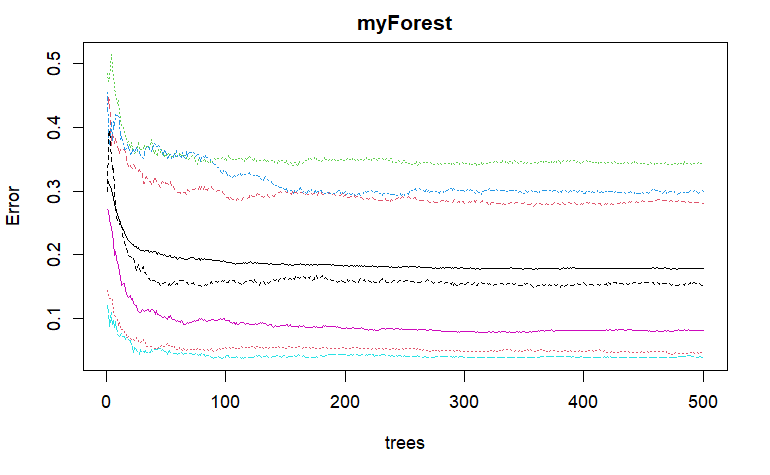

```r
#accuracy on training set = 82.2% which is much better!

# What other amounts can we try based on the error plot?
plot(myForest)
```

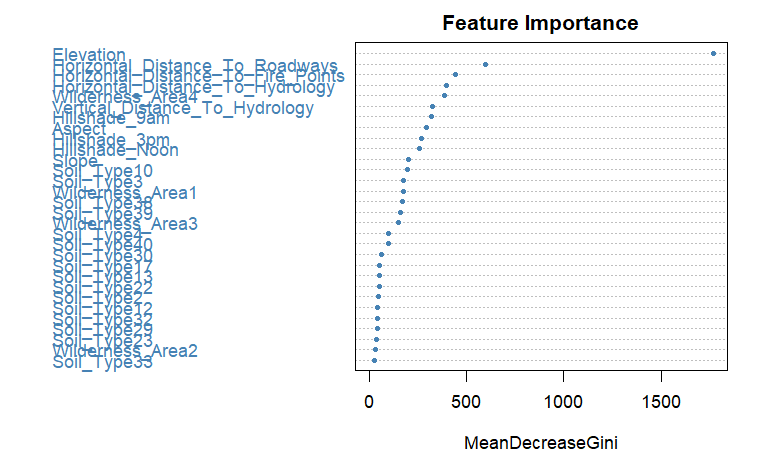

```r
# could mess with number of trees, and also mtry

# how about variable importance? Elevation is the clear winner
varImpPlot(myForest, main="Feature Importance", col="steelblue", pch=20)
```

```r
# predictions on test set
RFpred <- predict(myForest, newdata=forestTest)

# full confusion matrix for accuracy on test set
confusionMatrix(RFpred, forestTest$Cover_Type, positive='yes')
```

```
Confusion Matrix and Statistics

          Reference
Prediction   1   2   3   4   5   6   7
         1 467 120   0   0   0   0  24
         2 104 421   0   0  25   2   1
         3   0  18 450   1  13  58   0
         4   0   0  58 643   0  29   0
         5  19  60   5   0 618   4   1
         6   2  27 121   8   8 547   0
         7  43   4   0   0   0   0 611

Overall Statistics

               Accuracy : 0.8327
                 95% CI : (0.8215, 0.8435)
    No Information Rate : 0.1472
    P-Value [Acc > NIR] : < 2.2e-16

                  Kappa : 0.8048

 Mcnemar's Test P-Value : NA

Statistics by Class:

                     Class: 1 Class: 2 Class: 3 Class: 4 Class: 5 Class: 6 Class: 7
Sensitivity            0.7354  0.64769  0.70978   0.9862   0.9307   0.8547   0.9592
Specificity            0.9629  0.96582  0.97679   0.9775   0.9769   0.9571   0.9879
Pos Pred Value         0.7643  0.76130  0.83333   0.8808   0.8741   0.7672   0.9286
Neg Pred Value         0.9569  0.94216  0.95368   0.9976   0.9879   0.9755   0.9933
Prevalence             0.1407  0.14406  0.14051   0.1445   0.1472   0.1418   0.1412
Detection Rate         0.1035  0.09331  0.09973   0.1425   0.1370   0.1212   0.1354
Detection Prevalence   0.1354  0.12256  0.11968   0.1618   0.1567   0.1580   0.1458
Balanced Accuracy      0.8491  0.80676  0.84329   0.9818   0.9538   0.9059   0.9735
```

## Random Forest model accuracy = 83.3%